# COMPSCIX 415.2 Homework 1

Esa Eslami

6/11/2018

My Github repository for my assignments can be found at this URL: https://github.com/esaeslami/compscix-415-2-assignments

```r
library(mdsr)
library(tidyverse)
```

```r
data("WorldCities")
glimpse(WorldCities)
```

```
## Observations: 23,018
## Variables: 10
## $ code          <int> 3040051, 3041563, 290594, 291074, 291696, 292223...
## $ name          <chr> "les Escaldes", "Andorra la Vella", "Umm al Qayw...
## $ latitude      <dbl> 42.50729, 42.50779, 25.56473, 25.78953, 25.33132...
## $ longitude     <dbl> 1.53414, 1.52109, 55.55517, 55.94320, 56.34199, ...
## $ country       <chr> "AD", "AD", "AE", "AE", "AE", "AE", "AE", "AE", ...
## $ countryRegion <chr> "8", "7", "7", "5", "6", "3", "4", "6", "1", "4"...
## $ population    <dbl> 15853, 20430, 44411, 115949, 33575, 1137347, 263...
## $ regionCode    <int> 1033, 1037, 2, 2, 20, 11, 4, 6, 16, 15, 275, 4, ...
## $ region        <chr> "Europe/Andorra", "Europe/Andorra", "Asia/Dubai"...
## $ date          <chr> "10/15/08", "5/30/10", "11/3/12", "11/30/12", "1...
```

**QUESTION 1:** How many observations and variables are there in this data set? What are some of the variable names? Type up your answer in your document using complete sentences.

**ANSWER 1:** There are 23,018 observations and 10 variables in the “WorldCities” data set. The 10 variable names are: code, name, latitude, longitude, country, countryRegion, population, regionCode, region, and date.

**Extract parts of the data (*EXAMPLE*)**

```r
WorldCities <- head(WorldCities, 200) # 200 rows
country_col <- WorldCities$country
unique(country_col)
```

```
## [1] "AD" "AE" "AF" "AG" "AI" "AL" "AM" "AO" "AR"
```

**QUESTION 2:** There is a column called region in the data set. Can you extract this and show only the unique values?

**ANSWER 2:**

```r
region_col <- WorldCities$region
unique(region_col)
```

```
##  [1] "Europe/Andorra"                 "Asia/Dubai"
##  [3] "Asia/Kabul"                     "America/Antigua"
##  [5] "America/Anguilla"               "Europe/Tirane"
##  [7] "Asia/Yerevan"                   "Africa/Luanda"
##  [9] "America/Argentina/Buenos_Aires" "America/Argentina/Cordoba"
## [11] "America/Argentina/Salta"        "America/Argentina/Tucuman"
## [13] "America/Argentina/San_Juan"
```

**Extract/select data the tidy way (*EXAMPLE*)**

```r
country_col <- select(WorldCities, country)
country_col <- WorldCities %>% select(country)
WorldCities %>% select(region) %>% head(5)
```

```
##           region
## 1 Europe/Andorra
## 2 Europe/Andorra
## 3     Asia/Dubai
## 4     Asia/Dubai
## 5     Asia/Dubai
```

**QUESTION 3:** Can you extract and show the unique entries from the country column in WorldCities using one line of code and two %>% operators? The output will look like this:

```r
## country
## 1 AD
## 3 AE
## 15 AF
## 65 AG
## 66 AI
## 67 AL
## 87 AM
## 104 AO
## 131 AR
```

**ANSWER 3:**

```r
WorldCities %>% select(country) %>% unique()
```

```
##     country
## 1        AD
## 3        AE
## 15       AF
## 65       AG
## 66       AI
## 67       AL
## 87       AM
## 104      AO
## 131      AR
```

**Create a visualization (*EXAMPLE*)**

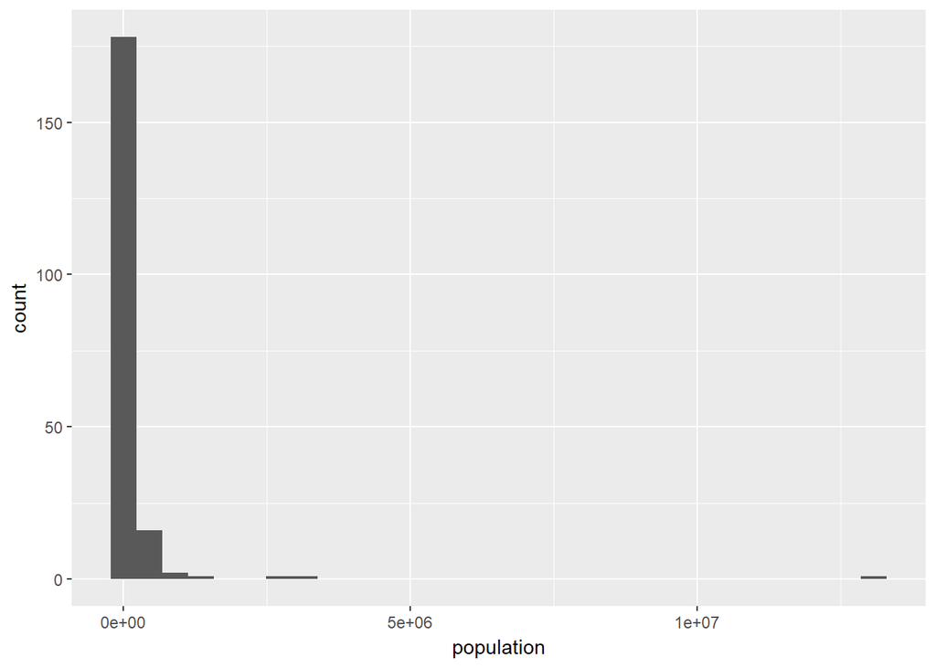

```r
WorldCities %>% ggplot(aes(x = population)) +
geom_histogram()
```

**QUESTION 4:** Make one more histogram of the population and add a new x-label, a new ylabel, a new title (use ggtitle(‘my title’)), and change the theme of the plot using theme_bw().

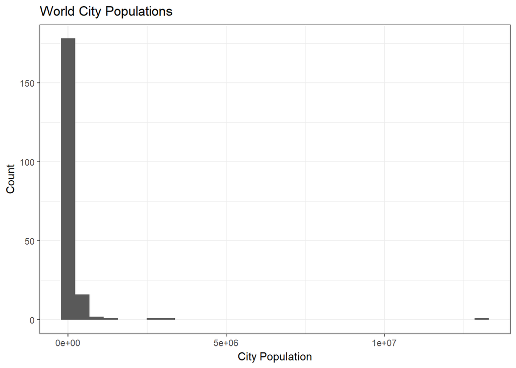

```r
WorldCities %>% ggplot(aes(x = population)) +
  geom_histogram() +
  xlab("City Population") +
  ylab("Count") +
  ggtitle('World City Populations') +
  theme_bw()
```